# Homework 06

## Question 1: Compare KNN and logistic regression

Use breast-cancer.csv, which contains 569 cases from the [Wisconsin Diagnostic Breast Cancer dataset](https://archive.ics.uci.edu/dataset/17/breast%2Bcancer%2Bwisconsin%2Bdiagnostic). Predict `y` (1 for malignant and 0 for benign) using `mean_radius`, `mean_texture`, and `mean_smoothness`.

Set a random seed and randomly split the observations into 70% training and 30% test data. Use the same split for every model. Standardize the predictors using the training means and standard deviations, and apply the same transformations to the test data.

Fit ordinary logistic regression with an intercept and no penalty, and KNN with Euclidean distance, equal neighbor weights, and

$$k\in\{5,15,25,35,45\}.$$

Using the estimated probabilities for `y = 1` on the test data, plot all six ROC curves in one figure and report their AUC values. Which of the six fitted models do you prefer? Give a brief justification based on your results.

```r
library(pROC)
bc <- read.csv("data/breast-cancer.csv")

predictor_names <- c("mean_radius", "mean_texture", "mean_smoothness")

set.seed(43261)

n <- nrow(bc)
train_idx <- sample(1:n, size = round(0.7 * n))

train_data <- bc[train_idx, ]
test_data  <- bc[-train_idx, ]

X_mean <- sapply(train_data[, predictor_names], mean)
X_sd   <- sapply(train_data[, predictor_names], sd)

standardize <- function(df) {
  scaled <- sweep(as.matrix(df[, predictor_names]), 2, X_mean, "-")
  sweep(scaled, 2, X_sd, "/")
}

X_train <- standardize(train_data)
X_test  <- standardize(test_data)
y_train <- train_data$y
y_test  <- test_data$y

# Logistic regression
log_fit <- glm(y ~ ., data = data.frame(y = y_train, X_train), family = binomial)
log_prob <- predict(log_fit, newdata = data.frame(X_test), type = "response")

# KNN probability: proportion of y = 1 among the k nearest training neighbors
knn_prob <- function(X_train, y_train, X_test, k) {
  d2 <- outer(rowSums(X_test^2), rowSums(X_train^2), "+") - 2 * X_test %*% t(X_train)
  apply(d2, 1, function(row) mean(y_train[order(row)[1:k]]))
}

k_values <- c(5, 15, 25, 35, 45)
knn_probs <- lapply(k_values, function(k) knn_prob(X_train, y_train, X_test, k))
names(knn_probs) <- paste0("k = ", k_values)

# Collect all six sets of probabilities
all_probs <- c(list("Logistic regression" = log_prob), knn_probs)

# ROC curves and AUC for all six models
roc_list <- lapply(all_probs, function(p) roc(y_test, p, quiet = TRUE))
auc_values <- sapply(roc_list, auc)

auc_table <- data.frame(model = names(all_probs), AUC = as.numeric(auc_values))
auc_table
```

```
                model       AUC
1 Logistic regression 0.9887541
2               k = 5 0.9656703
3              k = 15 0.9898639
4              k = 25 0.9906037
5              k = 35 0.9917135
6              k = 45 0.9927493
```

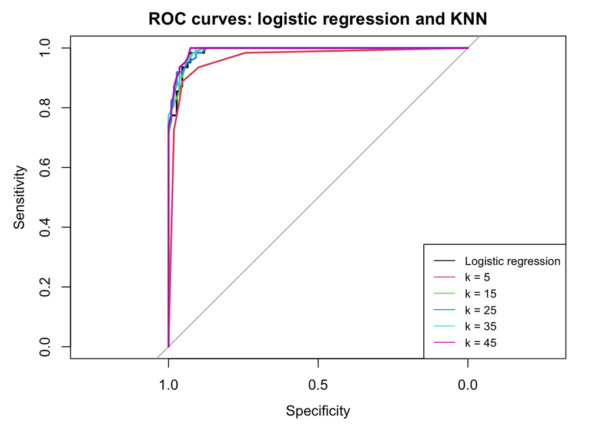

```r
plot(roc_list[[1]], col = 1, main = "ROC curves: logistic regression and KNN")
for (i in 2:length(roc_list)) {
  plot(roc_list[[i]], col = i, add = TRUE)
}
legend("bottomright", legend = names(all_probs), col = 1:length(all_probs), lty = 1, cex = 0.8)
```

Used the seed 43261. The AUC values for the six models are .9887541, 0.9656703, 0.9898639, 0.9906037, 0.9917135, 0.9927493. This means all the models performed very well. Each model does a good job seperating the two classes using just three predictors. The sixth model was the best pefroming model where k = 45, while the second model was the worst performing where k = 5.

I would prefer the sixth model where k = 45 because it has the highest AUC, but the AUC is still close to the other models, so it may not be a significant improvement. However, it is important to consider other factors such as interpretability and computational efficiency when choosing a model.

## Question 2: Training and test ROC curves

Use the same data, training/test split, and standardization as in Question 1. Fit KNN with Euclidean distance, equal neighbor weights, and

$$k\in\{1,3,5,10,20\}.$$

Use each fitted model to estimate probabilities for both the training and test observations. For training predictions, include each observation itself among its $k$ nearest neighbors.

For each $k$, use a separate panel to show the training and test ROC curves together. Report both AUC values.

Explain the difference between training and test performance and how it changes with $k$. In particular, explain what happens at $k=1$ and why training performance may not reflect performance on new observations.

```r
k_values_q2 <- c(1, 3, 5, 10, 20)

train_probs_q2 <- lapply(k_values_q2, function(k) knn_prob(X_train, y_train, X_train, k))
test_probs_q2  <- lapply(k_values_q2, function(k) knn_prob(X_train, y_train, X_test, k))

names(train_probs_q2) <- paste0("k = ", k_values_q2)
names(test_probs_q2)  <- paste0("k = ", k_values_q2)

train_roc_q2 <- lapply(train_probs_q2, function(p) roc(y_train, p, quiet = TRUE))
test_roc_q2  <- lapply(test_probs_q2,  function(p) roc(y_test,  p, quiet = TRUE))

train_auc_q2 <- sapply(train_roc_q2, auc)
test_auc_q2  <- sapply(test_roc_q2,  auc)

auc_table_q2 <- data.frame(k = k_values_q2,
                            train_AUC = as.numeric(train_auc_q2),
                            test_AUC  = as.numeric(test_auc_q2))
auc_table_q2
```

```
   k train_AUC  test_AUC
1  1 1.0000000 0.9022640
2  3 0.9883871 0.9496153
3  5 0.9823925 0.9656703
4 10 0.9781183 0.9834270
5 20 0.9772177 0.9907517
```

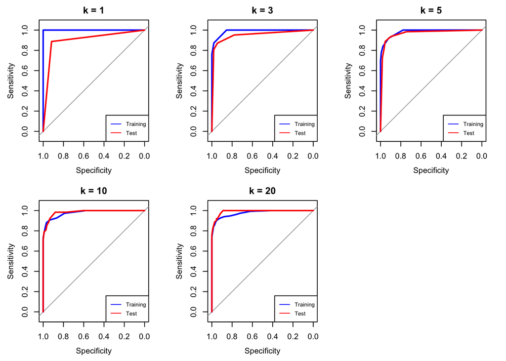

```r
par(mfrow = c(2, 3))
for (i in seq_along(k_values_q2)) {
  plot(train_roc_q2[[i]], col = "blue", main = paste0("k = ", k_values_q2[i]))
  plot(test_roc_q2[[i]], col = "red", add = TRUE)
  legend("bottomright", legend = c("Training", "Test"), col = c("blue", "red"), lty = 1, cex = 0.7)
}
par(mfrow = c(1, 1))
```

At k = 1, training AUC is exactly 1.0. Since every training observation’s single nearest neighbor is itself (distance 0), each training point gets a predicted probability of exactly 1 if it is malignant or exactly 0 if it is benign, with no actual averaging taking place. The model perfectly separates the training data because it has essentially memorized the labels rather than learned a generalizable pattern. The test AUC at k = 1 is 0.9023, well below every other test AUC in the table, reflecting genuine prediction on new observations using only 1 real neighbor, the noisiest and least stable estimate among the five values of k tried. The gap between training and test AUC at k = 1 is 0.098, the largest gap in the table by a wide margin.

As k increases from 1 to 20, training AUC steadily decreases, from 1.0 at k = 1 down to 0.977 at k = 20, since larger k means no training point can trivially rely on matching itself anymore, and each training prediction instead becomes a genuine average over several neighbors, some of which may disagree with that point’s own label. Test AUC moves in the opposite direction, rising from 0.902 at k = 1 to 0.991 at k = 20, since larger k reduces the variance of each probability estimate, improving its ability to generalize. By k = 10, test AUC (0.983) has actually overtaken training AUC (0.978), and by k = 20 the gap has reversed further (0.991 versus 0.977). The gap between the two narrows sharply after k = 1 and then flips sign.

This crossover makes the key point directly: training performance is not a reliable guide to performance on new data. Training AUC was highest exactly when the model was most clearly overfitting (k = 1, pure memorization), and it declined as the model became more genuinely useful. Test AUC, evaluated on observations the model never saw during fitting, is the only one of the two that reflects how the model will actually perform on new, unseen data, which is the quantity that matters in practice. Relying on training AUC alone here would have pointed toward k = 1, the worst-generalizing model of the five.

## Question 3: Peer evaluation of Homework 5

You will receive two Homework 5 submissions to review. The instructor’s GitHub account, **rqzhu-aide**, will open a **GitHub Issue** in the repository containing your Homework 5 submission. It will contain links to two other students’ repositories, where you can find their submitted homework reports.

Open your repository’s **Issues** tab on GitHub to find the assignment. You may ask AI to explain GitHub Issues or help you locate the assignment.

Choose **one specific mistake or item for improvement** from any question in either report.

1. **Identify the mistake or item for improvement.** State which report and question you selected, and briefly describe what is wrong or could be improved. Examples include incorrect code, a calculation error, a misinterpretation of results, a plot that could communicate the findings more clearly, or anything else you think could be done better.

Report: ethanmeng2004, Homework 5, Question 4 part c.

I think that an item for potential improvement is that the interprettion of the three misclassfied is too brief to support the claim that the errors are visually understandable.

2. **Explain your assessment.** Quote the relevant text, code, or figure caption exactly. Explain why the selected answer is incorrect or how it could be improved, referring to its reasoning, calculations, code, figures, or interpretation. **Complete this part yourself, without AI assistance.**

Each image is described by a simple sentence. For example, the 2 is described as “heavily curved” and the 4 is described as a “slanted shape”. The goal in this question is to find out why it specifically resembles the predicted digit as opposed to just describing the digit by itself. In this case, the students explanation is about general characteristics of what the digit looks like without mentioning how the predicted resembles the actual picture. If someone was to read this, they wouldn’t understand why the pixels are making the weird shapes. I do believe the answer is still a solid answer, but some extra detail would be helpful.

3. **Provide a correction.** Write a corrected or improved answer to the selected question, including any calculations, code, or figures needed.

A more informative version of part (c) would describe each misclassified image in terms of the specific pixel pattern it shares with its predicted label, not just a property of the true digit. For example, instead of “the round lower part of the 6 helps explain the prediction of 0,” a stronger interpretation would note that the 6’s lower loop, combined with a thin or faint upper stroke, leaves most of the image’s dark pixels concentrated in a single closed ring, which is the same pixel pattern that defines a typical 0; the misclassification follows directly from the fact that 5 of the image’s 256 pixels carrying the connecting stroke were not enough to outweigh that shared ring shape in Euclidean or Manhattan distance. Similarly, for the 2 classified as 0: a 2 drawn with a large rounded top and a weak, short bottom stroke loses the sharp corner and flat base that normally distinguish it from a 0, so again the dominant visual feature, the rounded upper curve, matches the closed-loop shape of a 0 more closely than it matches a typical 2’s more angular bottom. For the 4 classified as 7: if the diagonal stroke is drawn longer or darker than the vertical stroke, and the horizontal crossbar is short or faint, the image’s strongest edges resemble the top bar and diagonal of a 7 rather than the closed triangular gap that usually distinguishes a 4.

This version ties each misclassification to a specific, nameable pixel-level feature the two digits share, rather than describing the true digit’s appearance alone, which better supports the report’s own conclusion that the mistakes are visually understandable, since it shows concretely which part of the image created the confusion.

After completing your review, **open a GitHub Issue in the repository containing the report you selected**. Identify the report and question, and include your assessment and a detailed revision plan explaining what the author should change and why. Include a link to your posted GitHub Issue in your Homework 6 answer.

https://github.com/ethanmeng2004/stat432-fall2026/issues/2